```python
import numpy as np
import matplotlib.pyplot as plt
```

# [T] 5.6

## Example 5.6.1

The antiderivative of $e^x$ is, of course, itself. That makes evaluation of $∫_0^1 e^x dx$ the Fundamental Theorem trivial.

```python
exact = np.exp(1) - 1
print(exact)
```

```
1.718281828459045
```

The module scipy.integrate has multiple functions that estimate the value of an integral numerically without finding the antiderivative first. As you can see here, it’s often just as accurate.

```python
from scipy.integrate import quad
Q, errest = quad(np.exp, 0, 1, epsabs=1e-13, epsrel=1e-13)
print(Q,errest)
```

```
1.7182818284590453 1.9076760487502457e-14
```

The numerical approach is also far more robust. For example, $e^{sinx}$ has no useful antiderivative. But numerically, it’s no more difficult.

```python
Q, errest = quad(lambda x: np.exp(np.sin(x)), 0, 1, epsabs=1e-13, epsrel=1e-13)
print(Q)
```

```
1.6318696084180513
```

When you look at the graphs of these functions, what’s remarkable is that one of these areas is basic calculus while the other is almost impenetrable analytically. From a numerical standpoint, they are practically the same problem.

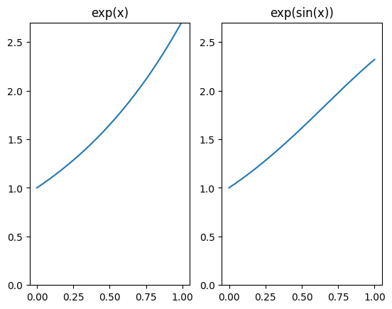

```python
x = np.linspace(0, 1, 300)
plt.subplot(1, 2, 1)
plt.plot(x, np.exp(x))
plt.ylim([0, 2.7]), plt.title("exp(x)")
plt.subplot(1, 2, 2)
plt.plot(x, np.exp(np.sin(x)))
plt.ylim([0, 2.7]), plt.title("exp(sin(x))");
```

## Trapezoid formula

```python
def trapezoid(f, a, b, n):
    """
    trapezoid(f, a, b, n)

    Apply the trapezoid integration formula for integrand f over interval [a,b], broken up into n equal pieces. Returns estimate, vector of nodes, and vector of integrand values at the nodes.
    """
    h = (b - a) / n
    t = np.linspace(a, b, n + 1)
    y = f(t)
    T = h * (np.sum(y[1:-1]) + 0.5 * (y[0] + y[-1]))
    return T, t, y
```

We will approximate the integral of the function $f(x)=e^{sin(7x)}$ over the interval $[0,2]$.

```python
f = lambda x: np.exp(np.sin(7 * x))
a, b = 0, 2
```

In lieu of the exact value, we will use the quad function to find an accurate result.

```python
from scipy.integrate import quad
I, errest = quad(f, a, b, epsabs=1e-13, epsrel=1e-13)
print(f"Integral = {I:.14f}")
```

```
Integral = 2.66321978276154
```

Here is the trapezoid result at n=40, and its error.

```python
T, t, y = trapezoid(f, a, b, 40)
print(f"Trapezoid estimate is {T:.14f} with error {I - T:.2e}")
```

```
Trapezoid estimate is 2.66230293560229 with error 9.17e-04
```

```python
n_ = 40 * 2 ** np.arange(6)
err = np.zeros(np.size(n_))
print("     n     error")
for k, n in enumerate(n_):
    T, t, y = trapezoid(f, a, b, n)
    err[k] = I - T
    print(f"{n:6d}   {err[k]:8.3e} ")
```

```
     n     error
    40   9.168e-04
    80   2.301e-04
   160   5.757e-05
   320   1.440e-05
   640   3.599e-06
  1280   8.998e-07
```

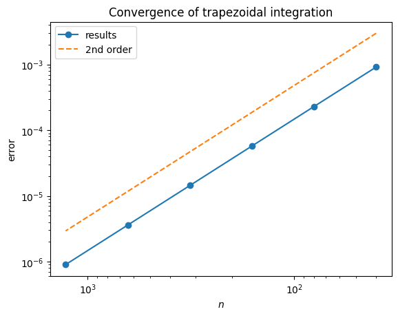

```python
plt.loglog(n_, abs(err), "-o", label="results")
plt.loglog(n_, 3e-3 * (n_ / n_[0]) ** (-2), "--", label="2nd order")
plt.gca().invert_xaxis()
plt.xlabel("$n$")
plt.ylabel("error")
plt.legend()
plt.title("Convergence of trapezoidal integration");
```

## Example 5.6.3

```python
from scipy.integrate import quad
f = lambda x: x**2 * np.exp(-2 * x)
a = 0
b = 2
I, errest = quad(f, a, b, epsabs=1e-13, epsrel=1e-13)
print(f"Integral = {I:.14f}")
```

```
Integral = 0.19047417361161
```

We start with the trapezoid formula on $n=N$ nodes.

```python
N = 20    # the coarsest formula
n = N
h = (b - a) / n
t = h * np.arange(n + 1)
y = f(t)
```

We can now apply weights to get the estimate $T_f(N)$.

```python
T = np.zeros(3)
T[0] = h * (sum(y[1:-1]) + y[0] / 2 + y[-1] / 2)
print(f"error (2nd order): {I - T[0]:.2e}")
```

```
error (2nd order): 6.27e-05
```

```python
n = 2 * n
h = h / 2
t = h * np.arange(n + 1)
T[1] = T[0] / 2 + h * sum(f(t[1:-1:2]))
print("error (2nd order):", I - T[:2])
```

```
error (2nd order): [6.27236723e-05 2.75002671e-05]
```

```python
n = 2 * n
h = h / 2
t = h * np.arange(n + 1)
T[2] = T[1] / 2 + h * sum(f(t[1:-1:2]))
print("error (2nd order):", I - T[:3])
```

```
error (2nd order): [6.27236723e-05 2.75002671e-05 1.27933290e-05]
```

Let us now do the first level of extrapolation to get results from Simpson's formula. We combine the elements T[i] and T[i+1] the same way for i=1 and i=2.

```python
S = np.array([(4 * T[i + 1] - T[i]) / 3 for i in range(2)])
print("error (4th order):", I - S)
```

```
error (4th order): [1.57591320e-05 7.89101624e-06]
```

With the two Simpson values $S_f(N)$ and $S_f(2N)$ in hand, we can do one more level of extrapolation to get a sixth-order accurate result.

```python
R = (16 * S[1] - S[0]) / 15
print("error (6th order):", I - R)
```

```
error (6th order): 7.366475186759702e-06
```

We can make a triangular table of the errors:

```python
!pip install prettyTable
from prettytable import PrettyTable
```

```python
results = PrettyTable()
results.add_column("2nd order", I - T)
results.add_column("4th order", np.concatenate(([np.nan],I - S)))
results.add_column("6th order", [np.nan, np.nan, I - R])
print(results)
```

```
+------------------------+------------------------+-----------------------+
|       2nd order        |       4th order        |       6th order       |
+------------------------+------------------------+-----------------------+
| 6.272367234605447e-05  |          nan           |          nan          |
| 2.7500267091584707e-05 | 1.5759132006770704e-05 |          nan          |
| 1.2793328951432592e-05 | 7.891016238020798e-06  | 7.366475186759702e-06 |
+------------------------+------------------------+-----------------------+
```

# [R1]

## methods for solving Ax = b

### Method 1: Row reduction and back substitution

### Method 2: LU decomposition

### Method 3: Inverse matrix

### Method 4: Cramer’s rule

### Time

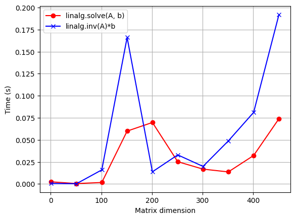

```python
import numpy as np
import matplotlib.pyplot as plt
from scipy import linalg as LA
from time import perf_counter as timer
N=np.arange(1,501,50)
rng = np.random.default_rng()
t1 = []
t2 = []
for n in N:
  A = rng.random((n,n))
  b = np.ones((n,1))
  tic = timer()
  x1 = LA.solve(A, b)
  toc = timer()
  t1.append(toc-tic)
  tic = timer()
  x2 = LA.inv(A)*b
  toc = timer()
  t2.append(toc-tic)
plt.plot(N,t1, '-ro',N,t2, '-bx')
plt.xlabel('Matrix dimension')
plt.ylabel('Time (s)')
plt.legend(['linalg.solve(A, b)',
'linalg.inv(A)*b'])
plt.grid('on')
plt.show()
```

Homework: Apply this method on midterm problem 3.

## Singular-Value Decomposition

[figure not shown]

```python
import numpy as np
import matplotlib.pyplot as plt
from matplotlib.widgets import Slider
from PIL import Image
from scipy.linalg import svd

import requests
from io import BytesIO

#A = Image.open('flowers.jpeg').convert('L')

url = 'https://www.math.ntu.edu.tw/sites/default/files/math_logo_w150_8081.jpg'
response = requests.get(url)
img = Image.open(BytesIO(response.content))
A = img.convert('L')

U, s, VT = svd(A)
def resize_image(N):
  return U[:,:N] @ np.diag(s[:N]) @ VT[:N,:]
fig,(ax1, ax2) = plt.subplots(1,2,
  figsize=(10,4))
plt.subplots_adjust(bottom=0.2)
ax1.set_xlim(1,len(s))
ax1.title.set_text('Singular values')
ax1.grid('on')
ax1.loglog(s,'ro-', markersize=3)
N = 10
image = resize_image(N)
ax2.imshow(image, cmap='gray')
axt = plt.axes([0.125, 0.1, 0.355, 0.05])
N_slide = Slider(axt, 'N',
  0, np.log10(len(s)),
  valstep=0.05, valinit=1)
N_slide.valtext.set_text(N)
def update(val):
  N = round(10**N_slide.val)
  N_slide.valtext.set_text(N)
  image = resize_image(N)
  ax2.imshow(image, cmap='gray')
  fig.canvas.draw_idle()
N_slide.on_changed(update)
plt.show()
```